# Construcción y validación del modelo de RLM

Modelar los ingresos semanales (kMXN) de un e-commerce a partir de 5 variables explicativas: - inversion_ads_kMXN (miles MXN invertidos en publicidad) - trafico_web_miles (miles de visitas) - alcance_redes_miles (miles) - indice_precio_rel (1 = paridad; >1 más caro que competidores) - descuento_pct (% promedio de descuento)

```r
library(readxl)
library(dplyr)
library(ggplot2)
library(GGally)
library(car) #vif durbin watson
library(lmtest) #bptest
library(MASS) #selección de variables del modelo
library(performance) #multicolinealidad
library(broom)
```

# Cargar los datos

```r
ruta <- "escenario_regresion_ecommerce.xlsx"
datos <- read_excel(ruta)
datos <- datos %>%
  mutate(across(where(is.character), as.numeric))
head(datos)
```

| semana | ingresos_kMXN | inversion_ads_kMXN | trafico_web_miles | alcance_redes_miles | indice_precio_rel | descuento_pct |
| --- | --- | --- | --- | --- | --- | --- |
| 1 | 1768.026 | 115.65362 | 137.0563 | 102.96227 | 1.1565042 | 9.250545 |
| 2 | 1595.844 | 47.58183 | 115.3684 | 40.91256 | 0.8174836 | 5.151156 |
| 3 | 1816.450 | 61.23029 | 142.7666 | 51.89437 | 1.2538994 | 7.828257 |
| 4 | 1910.060 | 75.44271 | 120.4166 | 68.30537 | 0.8575042 | 8.531951 |
| 5 | 1599.246 | 42.88681 | 128.1515 | 37.08543 | 1.1087003 | 8.557448 |
| 6 | 1677.919 | 45.48444 | 141.9380 | 38.09149 | 1.4224081 | 9.414516 |

# Exploración inicial

```r
summary(datos)
```

[output not shown]

Correlaciones

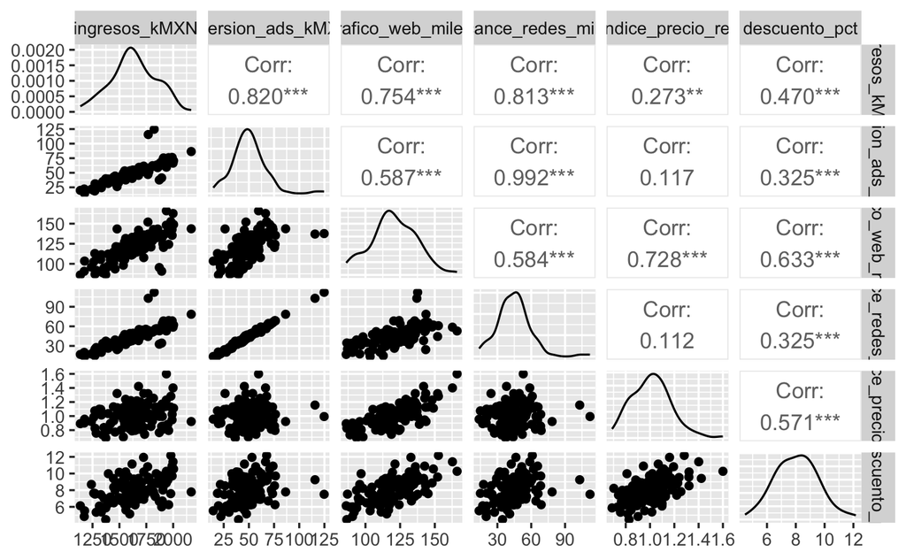

```r
pairs <- GGally::ggpairs(datos %>% dplyr :: select(-semana) )
print(pairs)
```

4. Modelo base

```r
m_full <- lm(ingresos_kMXN ~ inversion_ads_kMXN + trafico_web_miles + alcance_redes_miles + indice_precio_rel + descuento_pct, data = datos)
summary(m_full)
```

```
Call:
lm(formula = ingresos_kMXN ~ inversion_ads_kMXN + trafico_web_miles +
    alcance_redes_miles + indice_precio_rel + descuento_pct,
    data = datos)

Residuals:
    Min      1Q  Median      3Q     Max
-360.75  -33.19   -2.69   29.86  513.97

Coefficients:
                    Estimate Std. Error
(Intercept)          648.927     62.977
inversion_ads_kMXN     8.242      4.025
trafico_web_miles      8.678      1.118
alcance_redes_miles   -3.191      4.436
indice_precio_rel   -418.347     92.275
descuento_pct         11.445      7.240
                    t value Pr(>|t|)
(Intercept)          10.304  < 2e-16 ***
inversion_ads_kMXN    2.048   0.0429 *
trafico_web_miles     7.762 3.91e-12 ***
alcance_redes_miles  -0.719   0.4734
indice_precio_rel    -4.534 1.44e-05 ***
descuento_pct         1.581   0.1167
---
Signif. codes:
  0 ‘***’ 0.001 ‘**’ 0.01 ‘*’ 0.05 ‘.’
  0.1 ‘ ’ 1

Residual standard error: 90.25 on 114 degrees of freedom
Multiple R-squared:  0.8196,    Adjusted R-squared:  0.8117
F-statistic: 103.6 on 5 and 114 DF,  p-value: < 2.2e-16
```

# Diagnóstico de multicolinealidad

Se dice que existe multicolinealidad entre las variables independientes si estas variables están relacionadas entre sí o dependen la una de la otra.

Factor de inflación de la varianza:
$$VIF_j = \frac{1}{1-R^2_j}$$
Si tenemos algún VIF mayor que 10 asumiremos que existe multicolinealidad.

Si el promedio de todos los VIF sean mucho mayores que 1.

```r
vif_vals <- car::vif(m_full)
vif_vals
```

```
 inversion_ads_kMXN   trafico_web_miles
          65.176413            4.944727
alcance_redes_miles   indice_precio_rel
          65.204074            3.241997
      descuento_pct
           1.750341
```

```r
m_1 <- lm(ingresos_kMXN ~  trafico_web_miles + alcance_redes_miles + indice_precio_rel + descuento_pct, data = datos)
summary(m_1)
```

```
Call:
lm(formula = ingresos_kMXN ~ trafico_web_miles + alcance_redes_miles +
    indice_precio_rel + descuento_pct, data = datos)

Residuals:
    Min      1Q  Median      3Q     Max
-349.08  -33.66   -4.51   37.35  538.03

Coefficients:
                     Estimate Std. Error
(Intercept)          649.7251    63.8442
trafico_web_miles      8.8371     1.1306
alcance_redes_miles    5.7349     0.8306
indice_precio_rel   -422.2283    93.5272
descuento_pct         11.0394     7.3370
                    t value Pr(>|t|)
(Intercept)          10.177  < 2e-16 ***
trafico_web_miles     7.817 2.84e-12 ***
alcance_redes_miles   6.904 2.94e-10 ***
indice_precio_rel    -4.514 1.54e-05 ***
descuento_pct         1.505    0.135
---
Signif. codes:
  0 ‘***’ 0.001 ‘**’ 0.01 ‘*’ 0.05 ‘.’
  0.1 ‘ ’ 1

Residual standard error: 91.5 on 115 degrees of freedom
Multiple R-squared:  0.813, Adjusted R-squared:  0.8065
F-statistic:   125 on 4 and 115 DF,  p-value: < 2.2e-16
```

```r
m_2 <- lm(ingresos_kMXN ~ inversion_ads_kMXN +  alcance_redes_miles + indice_precio_rel + descuento_pct, data = datos)
summary(m_2)
```

```
Call:
lm(formula = ingresos_kMXN ~ inversion_ads_kMXN + alcance_redes_miles +
    indice_precio_rel + descuento_pct, data = datos)

Residuals:
    Min      1Q  Median      3Q     Max
-529.65  -56.50    3.89   51.03  414.69

Coefficients:
                    Estimate Std. Error
(Intercept)          854.227     70.354
inversion_ads_kMXN    10.420      4.943
alcance_redes_miles   -1.095      5.450
indice_precio_rel    106.562     77.284
descuento_pct         24.633      8.663
                    t value Pr(>|t|)
(Intercept)          12.142  < 2e-16 ***
inversion_ads_kMXN    2.108  0.03720 *
alcance_redes_miles  -0.201  0.84105
indice_precio_rel     1.379  0.17062
descuento_pct         2.843  0.00528 **
---
Signif. codes:
  0 ‘***’ 0.001 ‘**’ 0.01 ‘*’ 0.05 ‘.’
  0.1 ‘ ’ 1

Residual standard error: 111.1 on 115 degrees of freedom
Multiple R-squared:  0.7243,    Adjusted R-squared:  0.7147
F-statistic: 75.53 on 4 and 115 DF,  p-value: < 2.2e-16
```

```r
m_3 <- lm(ingresos_kMXN ~ alcance_redes_miles + indice_precio_rel + descuento_pct, data = datos)
summary(m_3)
```

```
Call:
lm(formula = ingresos_kMXN ~ alcance_redes_miles + indice_precio_rel +
    descuento_pct, data = datos)

Residuals:
    Min      1Q  Median      3Q     Max
-509.47  -56.74   -8.31   64.65  435.61

Coefficients:
                    Estimate Std. Error
(Intercept)         860.0360    71.3365
alcance_redes_miles  10.2929     0.7288
indice_precio_rel   113.8921    78.3437
descuento_pct        24.4263     8.7902
                    t value Pr(>|t|)
(Intercept)          12.056  < 2e-16 ***
alcance_redes_miles  14.123  < 2e-16 ***
indice_precio_rel     1.454  0.14872
descuento_pct         2.779  0.00637 **
---
Signif. codes:
  0 ‘***’ 0.001 ‘**’ 0.01 ‘*’ 0.05 ‘.’
  0.1 ‘ ’ 1

Residual standard error: 112.7 on 116 degrees of freedom
Multiple R-squared:  0.7136,    Adjusted R-squared:  0.7062
F-statistic: 96.36 on 3 and 116 DF,  p-value: < 2.2e-16
```

#Seleccion de las variables

AIC: coeficiente de información de AIKAIKE y es una métrica que indica que tan bueno es el ajuste de los datos a un modelo específico. (Relativa)

```r
m_null <- lm(ingresos_kMXN ~ 1 , data= datos)
step_fwd <- stepAIC(m_null,
                    scope = list(lower = m_null, upper = m_full,
                              direction="forward", trace = TRUE))
```

```
Start:  AIC=1282
ingresos_kMXN ~ 1

                      Df Sum of Sq     RSS
+ inversion_ads_kMXN   1   3464743 1683373
+ alcance_redes_miles  1   3402649 1745467
+ trafico_web_miles    1   2927410 2220706
+ descuento_pct        1   1138910 4009206
+ indice_precio_rel    1    385039 4763077
<none>                             5148116
                         AIC
+ inversion_ads_kMXN  1149.9
+ alcance_redes_miles 1154.2
+ trafico_web_miles   1183.1
+ descuento_pct       1254.0
+ indice_precio_rel   1274.7
<none>                1282.0

Step:  AIC=1149.86
ingresos_kMXN ~ inversion_ads_kMXN

                      Df Sum of Sq     RSS
+ trafico_web_miles    1    582868 1100505
+ descuento_pct        1    239594 1443779
+ indice_precio_rel    1    164208 1519165
<none>                             1683373
+ alcance_redes_miles  1       347 1683026
- inversion_ads_kMXN   1   3464743 5148116
                         AIC
+ trafico_web_miles   1100.8
+ descuento_pct       1133.4
+ indice_precio_rel   1139.5
<none>                1149.9
+ alcance_redes_miles 1151.8
- inversion_ads_kMXN  1282.0

Step:  AIC=1100.85
ingresos_kMXN ~ inversion_ads_kMXN + trafico_web_miles

                      Df Sum of Sq     RSS
```

[output cut: 35 more lines]

```

                      Df Sum of Sq     RSS
<none>                              932778
- descuento_pct        1     19693  952471
+ alcance_redes_miles  1      4215  928563
- indice_precio_rel    1    164163 1096942
- inversion_ads_kMXN   1    429013 1361791
- trafico_web_miles    1    487066 1419845
                         AIC
<none>                1085.0
- descuento_pct       1085.5
+ alcance_redes_miles 1086.5
- indice_precio_rel   1102.5
- inversion_ads_kMXN  1128.4
- trafico_web_miles   1133.4
```

```r
modelo <- lm(ingresos_kMXN ~ inversion_ads_kMXN + trafico_web_miles + indice_precio_rel, data=datos)
summary(modelo)
```

```
Call:
lm(formula = ingresos_kMXN ~ inversion_ads_kMXN + trafico_web_miles +
    indice_precio_rel, data = datos)

Residuals:
    Min      1Q  Median      3Q     Max
-379.56  -31.81   -1.67   33.17  515.30

Coefficients:
                    Estimate Std. Error
(Intercept)         659.3045    62.9346
inversion_ads_kMXN    5.4560     0.7455
trafico_web_miles     9.0408     1.0883
indice_precio_rel  -383.9244    90.4194
                   t value Pr(>|t|)
(Intercept)         10.476  < 2e-16 ***
inversion_ads_kMXN   7.318 3.55e-11 ***
trafico_web_miles    8.308 2.08e-13 ***
indice_precio_rel   -4.246 4.41e-05 ***
---
Signif. codes:
  0 ‘***’ 0.001 ‘**’ 0.01 ‘*’ 0.05 ‘.’
  0.1 ‘ ’ 1

Residual standard error: 90.61 on 116 degrees of freedom
Multiple R-squared:  0.815, Adjusted R-squared:  0.8102
F-statistic: 170.3 on 3 and 116 DF,  p-value: < 2.2e-16
```

# Validación de los supuestos.

Linealidad: Las variables independientes realmente explican a la variable dependiente mediante un modelo lineal.

```r
resettest(modelo, power = 2:3 ,type = "fitted")
```

```
    RESET test

data:  modelo
RESET = 15.587, df1 = 2, df2 = 114,
p-value = 1.038e-06
```

Normalidad de los residuos.

```r
shapiro.test(residuals(modelo))
```

```
    Shapiro-Wilk normality test

data:  residuals(modelo)
W = 0.7123, p-value = 5.029e-14
```

Homocedasticidad

```r
bptest(modelo)
```

```
    studentized Breusch-Pagan test

data:  modelo
BP = 17.266, df = 3, p-value =
0.000623
```

Independencia

```r
durbinWatsonTest(modelo)
```

```
 lag Autocorrelation D-W Statistic p-value
   1     -0.00391826      1.901942    0.52
 Alternative hypothesis: rho != 0
```

NOTA: En el análisis anterior solamente se cumple el supuesto de independencia.

Para que se cumplan los supuestos es necesario obtener valores p mayores que 0.05 en las pruebas de linealidad, normalidad, homocedasticidad e independencia.